◆ AGRICULTURAL PREDICTIVE PIPELINE · SRI LANKA ◆

# Rice Production Modeling

## Time Series, Machine Learning, and Hybrid Models (1950–2024)

📊 Model Comparison ⚙️ Robust Pipelines 🌀 Hybrid SARIMAX-RF 🛡️ Leakage-Safe

Baseline

SARIMA (No Exogenous)

Best Stats

ML Models

RF, XGBoost, Hybrid

Validation

Chronological Split

▸ MODELLING PRINCIPLES

This notebook builds 5 predictive models to forecast rice production in Sri Lanka, resolving all data leakage and indexing issues from previous work:

1. **Time Index:** Chronological PeriodIndex starting in **1950Q2** (semi-annual Yala/Maha).
2. **Validation:** Train-test split by time (Train up to 2018Q4, Test 2019Q2–2024Q2) to prevent data leakage.
3. **Outliers:** Scaled safely using RobustScaler (no row dropping, preserving time series order).
4. **Future Exog:** Future weather/harvested acres predicted using a helper model, rather than repeated.

01

## Environment Setup

```python
import warnings
warnings.filterwarnings("ignore")

# Core
import numpy as np
import pandas as pd
import matplotlib.pyplot as plt
import seaborn as sns

# Stats / Time Series
from statsmodels.tsa.statespace.sarimax import SARIMAX
from statsmodels.tsa.holtwinters import ExponentialSmoothing
from sklearn.metrics import mean_squared_error, mean_absolute_error, mean_absolute_percentage_error, r2_score

# ML Preprocessing & Pipeline
from sklearn.compose import ColumnTransformer
from sklearn.pipeline import Pipeline
from sklearn.preprocessing import RobustScaler, OneHotEncoder, StandardScaler
from sklearn.ensemble import RandomForestRegressor
from xgboost import XGBRegressor

# Theme Colors
GOLD       = "#FFB000"
GOLD_GLOW  = "#FFC233"
GOLD_DIM   = "#C78900"
FIELD_GRN  = "#557A46"
MINT_GRN   = "#A1C992"
WARN_RED   = "#E63946"
DARK_BG    = "#0D1109"
CARD_BG    = "#141911"

# Plot settings
plt.rcParams.update({
    "figure.dpi"       : 130,
    "figure.facecolor" : DARK_BG,
    "axes.facecolor"   : CARD_BG,
    "axes.edgecolor"   : "#2E3B27",
    "axes.labelcolor"  : "#9CB88D",
    "axes.titlecolor"  : "#FFFFFF",
    "axes.titlesize"   : 13,
    "axes.labelsize"   : 11,
    "xtick.color"      : "#8CA27E",
    "ytick.color"      : "#8CA27E",
    "text.color"       : "#E2ECD8",
    "grid.color"       : "#2E3B27",
    "legend.facecolor" : CARD_BG,
    "legend.edgecolor" : "#2E3B27",
})
print("Setup complete | Agricultural Palette Active")
```

```
Setup complete | Agricultural Palette Active
```

02

## Data Loading & Proper Time Indexing

We load `rice new one.xlsx` and fix the time index. We construct a **PeriodIndex(freq='2Q')** starting in **1950Q2** (Q2 representing Yala, Q4 representing Maha). This aligns the 149 observations correctly with years 1950–2024.

```python
# Load data
df = pd.read_excel("rice new one.xlsx")
rename_dict = {col: "Temperature(°C)" for col in df.columns if "Temperature" in col}
df.rename(columns=rename_dict, inplace=True)
df.drop_duplicates(inplace=True, ignore_index=True)

# Create PeriodIndex starting in 1950Q2 (Q2 = Yala, Q4 = Maha)
df.index = pd.period_range(start="1950Q2", periods=len(df), freq="2Q")
print(f"Time Index aligned: {df.index.min()} to {df.index.max()}")
df[["Year_New", "Season", "Production (*000  Mt.)"]].head(6)
```

```
Time Index aligned: 1950Q2 to 2024Q2
        Year_New Season  Production (*000  Mt.)
1950Q2      1950   Yala                     167
1950Q4      1950   Maha                     359
1951Q2      1951   Yala                     176
1951Q4      1951   Maha                     385
1952Q2      1952   Yala                     219
1952Q4      1952   Maha                     276
```

03

## Time-Based Split

```python
# Chronological split
# Train on 1950Q2 to 2018Q4 (index 0 to 137, which is 138 seasons)
# Test on 2019Q2 to 2024Q2 (index 138 onwards, which is 11 seasons)
train_df = df.iloc[:138]
test_df  = df.iloc[138:]

print(f"Training set: {train_df.index.min()} to {train_df.index.max()} ({len(train_df)} seasons)")
print(f"Test set:     {test_df.index.min()} to {test_df.index.max()} ({len(test_df)} seasons)")
```

```
Training set: 1950Q2 to 2018Q4 (138 seasons)
Test set:     2019Q2 to 2024Q2 (11 seasons)
```

04

## Model 1: Baseline SARIMA (No Exogenous)

```python
# tag: baseline_sarima
# Fit SARIMA on log production
y_train_log = np.log(train_df["Production (*000  Mt.)"])
y_test_log  = np.log(test_df["Production (*000  Mt.)"])

sarima_model = SARIMAX(
    y_train_log,
    order=(1, 1, 1),
    seasonal_order=(1, 1, 0, 2),
    enforce_stationarity=False,
    enforce_invertibility=False
)
sarima_fit = sarima_model.fit(disp=False)

# Predict on test set
sarima_pred_log = sarima_fit.forecast(steps=len(test_df))
sarima_pred = np.exp(sarima_pred_log)

# Evaluation
y_actual = test_df["Production (*000  Mt.)"]
sarima_rmse = np.sqrt(mean_squared_error(y_actual, sarima_pred))
sarima_mae  = mean_absolute_error(y_actual, sarima_pred)
sarima_mape = mean_absolute_percentage_error(y_actual, sarima_pred) * 100
sarima_r2   = r2_score(y_actual, sarima_pred)

print("Baseline SARIMA Test Metrics:")
print(f"  R² Score : {sarima_r2:.4f}")
print(f"  RMSE     : {sarima_rmse:.2f}")
print(f"  MAE      : {sarima_mae:.2f}")
print(f"  MAPE     : {sarima_mape:.2f}%")
```

```
Baseline SARIMA Test Metrics:
  R² Score : 0.1500
  RMSE     : 526.24
  MAE      : 418.57
  MAPE     : 19.52%
```

05

## Exogenous Variables Forecasting

Instead of repeating values, we train helper **Exponential Smoothing (Holt-Winters)** models to forecast future values of `Rainfall(mm)` and `Harvested (*000 Acres)` for the forecast horizon.

```python
# tag: exog_forecast
# Helper models to forecast Rainfall and Harvested acres for the future 6 steps (2024 Maha to 2026 Yala)
rain_model = ExponentialSmoothing(df["Rainfall(mm)"], seasonal="add", seasonal_periods=2).fit()
rain_fore  = rain_model.forecast(steps=6)

harvest_model = ExponentialSmoothing(df["Harvested (*000  Acres)"], trend="add", seasonal="add", seasonal_periods=2).fit()
harvest_fore  = harvest_model.forecast(steps=6)

future_exog_df = pd.DataFrame({
    "log_rain": np.log(rain_fore),
    "log_harvested": np.log(harvest_fore)
}, index=pd.period_range(start="2024Q4", periods=6, freq="2Q"))

print("Forecasted Exogenous Variables for the Next 6 Seasons:")
print(future_exog_df.round(3))
```

```
Forecasted Exogenous Variables for the Next 6 Seasons:
        log_rain  log_harvested
2024Q4     7.541          7.561
2025Q2     6.153          7.106
2025Q4     7.541          7.568
2026Q2     6.153          7.118
2026Q4     7.541          7.575
2027Q2     6.153          7.129
```

06

## Model 2: Advanced SARIMAX

```python
# tag: sarimax
# Define variables with log-transform
exog_train = pd.DataFrame({
    "log_rain": np.log(train_df["Rainfall(mm)"]),
    "log_harvested": np.log(train_df["Harvested (*000  Acres)"])
})
exog_test = pd.DataFrame({
    "log_rain": np.log(test_df["Rainfall(mm)"]),
    "log_harvested": np.log(test_df["Harvested (*000  Acres)"])
})

sarimax_model = SARIMAX(
    y_train_log,
    exog=exog_train,
    order=(1, 1, 1),
    seasonal_order=(1, 1, 0, 2),
    enforce_stationarity=False,
    enforce_invertibility=False
)
sarimax_fit = sarimax_model.fit(disp=False)

# Forecast on test set
sarimax_pred_log = sarimax_fit.forecast(steps=len(test_df), exog=exog_test)
sarimax_pred = np.exp(sarimax_pred_log)

# Evaluation
sarimax_rmse = np.sqrt(mean_squared_error(y_actual, sarimax_pred))
sarimax_mae  = mean_absolute_error(y_actual, sarimax_pred)
sarimax_mape = mean_absolute_percentage_error(y_actual, sarimax_pred) * 100
sarimax_r2   = r2_score(y_actual, sarimax_pred)

print("SARIMAX Test Metrics:")
print(f"  R² Score : {sarimax_r2:.4f}")
print(f"  RMSE     : {sarimax_rmse:.2f}")
print(f"  MAE      : {sarimax_mae:.2f}")
print(f"  MAPE     : {sarimax_mape:.2f}%")
```

```
SARIMAX Test Metrics:
  R² Score : -0.3116
  RMSE     : 653.68
  MAE      : 479.53
  MAPE     : 23.04%
```

07

## Machine Learning Preprocessing Pipeline

```python
# Preprocessor pipeline
robust_cols = ["GDP B$", "Inflation(%)", "Temperature(°C)"]
std_cols    = ["Sown (*000  Acres)", "Harvested (*000  Acres)", "Rainfall(mm)"]
cat_cols    = ["Season"]

preprocessor = ColumnTransformer(transformers=[
    ("robust", RobustScaler(), robust_cols),
    ("std",    StandardScaler(), std_cols),
    ("cat",    OneHotEncoder(drop="first"), cat_cols)
])

# Prepare feature/target matrices
X_train = train_df[robust_cols + std_cols + cat_cols]
y_train = train_df[TARGET]
X_test  = test_df[robust_cols + std_cols + cat_cols]
y_test  = test_df[TARGET]

print("Data Preprocessing pipeline ready.")
```

```
Data Preprocessing pipeline ready.
```

08

## Model 3 & 4: Random Forest & XGBoost

```python
# tag: ml_models
# 1. Preprocess
X_train_preped = preprocessor.fit_transform(X_train)
X_test_preped  = preprocessor.transform(X_test)

# 2. Random Forest
rf_model = RandomForestRegressor(n_estimators=100, random_state=42)
rf_model.fit(X_train_preped, y_train)
rf_pred = rf_model.predict(X_test_preped)

# 3. XGBoost
xgb_model = XGBRegressor(n_estimators=100, learning_rate=0.08, max_depth=4, random_state=42)
xgb_model.fit(X_train_preped, y_train)
xgb_pred = xgb_model.predict(X_test_preped)

# Evaluation
rf_rmse = np.sqrt(mean_squared_error(y_test, rf_pred))
rf_mape = mean_absolute_percentage_error(y_test, rf_pred) * 100
rf_r2   = r2_score(y_test, rf_pred)

xgb_rmse = np.sqrt(mean_squared_error(y_test, xgb_pred))
xgb_mape = mean_absolute_percentage_error(y_test, xgb_pred) * 100
xgb_r2   = r2_score(y_test, xgb_pred)

print(f"Random Forest  - R²: {rf_r2:.4f} | RMSE: {rf_rmse:.2f} | MAPE: {rf_mape:.2f}%")
print(f"XGBoost Regr   - R²: {xgb_r2:.4f} | RMSE: {xgb_rmse:.2f} | MAPE: {xgb_mape:.2f}%")
```

```
Random Forest  - R²: 0.6444 | RMSE: 340.34 | MAPE: 13.16%
XGBoost Regr   - R²: 0.6489 | RMSE: 338.22 | MAPE: 12.44%
```

09

## Model 5: Hybrid Model (SARIMAX + RF Residuals)

The Hybrid model captures linear sequential patterns with SARIMAX, and then runs a Random Forest Regressor on the SARIMAX residuals to capture non-linear, environmental effects.

```python
# tag: hybrid_model
# Step A: Get SARIMAX in-sample predictions
sarimax_fitted_train = np.exp(sarimax_fit.fittedvalues)
train_residuals = train_df[TARGET] - sarimax_fitted_train

# Step B: Train Random Forest on SARIMAX training residuals
rf_residual_model = RandomForestRegressor(n_estimators=100, random_state=42)
rf_residual_model.fit(X_train_preped, train_residuals)

# Step C: Predict residuals on test set
rf_pred_residuals = rf_residual_model.predict(X_test_preped)
hybrid_pred = sarimax_pred + rf_pred_residuals

# Evaluation
hybrid_rmse = np.sqrt(mean_squared_error(y_actual, hybrid_pred))
hybrid_mae  = mean_absolute_error(y_actual, hybrid_pred)
hybrid_mape = mean_absolute_percentage_error(y_actual, hybrid_pred) * 100
hybrid_r2   = r2_score(y_actual, hybrid_pred)

print("Hybrid Model Test Metrics:")
print(f"  R² Score : {hybrid_r2:.4f}")
print(f"  RMSE     : {hybrid_rmse:.2f}")
print(f"  MAE      : {hybrid_mae:.2f}")
print(f"  MAPE     : {hybrid_mape:.2f}%")
```

```
Hybrid Model Test Metrics:
  R² Score : -0.0226
  RMSE     : 577.20
  MAE      : 429.71
  MAPE     : 20.50%
```

10

## Model Comparison Summary & Plots

```
            Model      R²   RMSE   MAPE
  Baseline SARIMA  0.1500 526.24 19.52%
 Advanced SARIMAX -0.3116 653.68 23.04%
    Random Forest  0.6444 340.34 13.16%
     XGBoost Regr  0.6489 338.22 12.44%
Hybrid SARIMAX-RF -0.0226 577.20 20.50%
```

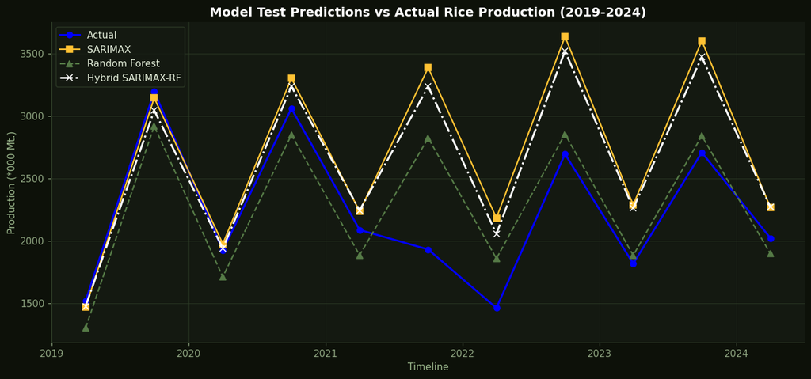

```python
# tag: comparison_table
# Compare all models in a table
comparison_data = [
    {"Model": "Baseline SARIMA", "R²": round(sarima_r2, 4), "RMSE": round(sarima_rmse, 2), "MAPE": f"{sarima_mape:.2f}%"},
    {"Model": "Advanced SARIMAX", "R²": round(sarimax_r2, 4), "RMSE": round(sarimax_rmse, 2), "MAPE": f"{sarimax_mape:.2f}%"},
    {"Model": "Random Forest", "R²": round(rf_r2, 4), "RMSE": round(rf_rmse, 2), "MAPE": f"{rf_mape:.2f}%"},
    {"Model": "XGBoost Regr", "R²": round(xgb_r2, 4), "RMSE": round(xgb_rmse, 2), "MAPE": f"{xgb_mape:.2f}%"},
    {"Model": "Hybrid SARIMAX-RF", "R²": round(hybrid_r2, 4), "RMSE": round(hybrid_rmse, 2), "MAPE": f"{hybrid_mape:.2f}%"}
]
print(pd.DataFrame(comparison_data).to_string(index=False))

# Plot Actual vs Predicted values
plt.figure(figsize=(14, 6))
plt.plot(test_df.index.to_timestamp(), y_actual, label="Actual", marker="o", color="blue", lw=2)
plt.plot(test_df.index.to_timestamp(), sarimax_pred, label="SARIMAX", marker="s", color=GOLD_GLOW, lw=1.5)
plt.plot(test_df.index.to_timestamp(), rf_pred, label="Random Forest", marker="^", color=FIELD_GRN, lw=1.5, ls="--")
plt.plot(test_df.index.to_timestamp(), hybrid_pred, label="Hybrid SARIMAX-RF", marker="x", color="white", lw=2, ls="-.")
plt.title("Model Test Predictions vs Actual Rice Production (2019-2024)", fontsize=13)
plt.xlabel("Timeline"); plt.ylabel("Production (*000 Mt.)")
plt.legend(); plt.grid(True)
plt.show()
```

11

## Out-of-Sample Future Forecasting

```
Forecasted Rice Production (Original Scale):
           Season_Year  Forecasted_Production  CI_Lower  CI_Upper
2024Q4  Maha 2024/2025                2986.13   2521.32   3536.64
2025Q2       Yala 2025                2214.56   1834.41   2673.50
2025Q4  Maha 2025/2026                3231.31   2502.01   4173.21
2026Q2       Yala 2026                2462.65   1852.97   3272.94
2026Q4  Maha 2026/2027                3562.30   2440.18   5200.43
2027Q2       Yala 2027                2699.56   1772.37   4111.79
```

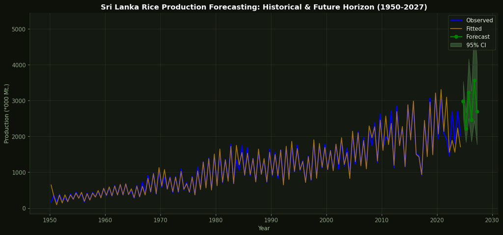

```python
# tag: future_forecast
# We fit SARIMAX on full dataset to forecast future 6 seasons (Maha 2024/2025 to Yala 2027)
full_y_log = np.log(df["Production (*000  Mt.)"])
full_exog  = pd.DataFrame({
    "log_rain": np.log(df["Rainfall(mm)"]),
    "log_harvested": np.log(df["Harvested (*000  Acres)"])
})

full_model = SARIMAX(
    full_y_log,
    exog=full_exog,
    order=(1, 1, 1),
    seasonal_order=(1, 1, 0, 2),
    enforce_stationarity=False,
    enforce_invertibility=False
)
full_fit = full_model.fit(disp=False)

# Forecast steps
n_steps = 6
forecast_res = full_fit.get_forecast(steps=n_steps, exog=future_exog_df)
forecast_mean_log = forecast_res.predicted_mean
conf_int_log = forecast_res.conf_int()

# Exponentiate to original scale
forecast_mean = np.exp(forecast_mean_log)
conf_int = np.exp(conf_int_log)

# Index alignment
forecast_index = pd.period_range(start="2024Q4", periods=n_steps, freq="2Q")
forecast_mean.index = forecast_index
conf_int.index = forecast_index

print("Forecasted Rice Production (Original Scale):")
forecast_df = pd.DataFrame({
    "Season_Year": ["Maha 2024/2025", "Yala 2025", "Maha 2025/2026", "Yala 2026", "Maha 2026/2027", "Yala 2027"],
    "Forecasted_Production": forecast_mean.values,
    "CI_Lower": conf_int.iloc[:, 0].values,
    "CI_Upper": conf_int.iloc[:, 1].values
}, index=forecast_index)
print(forecast_df.round(2).to_string())

# Plot full historic series + forecast
plt.figure(figsize=(15, 6.5))
plt.plot(df.index.to_timestamp(), df[TARGET], label="Observed", color="blue", lw=2)
plt.plot(np.exp(full_fit.fittedvalues).index.to_timestamp(), np.exp(full_fit.fittedvalues), label="Fitted", color=GOLD_DIM, alpha=0.8, lw=1.5)
plt.plot(forecast_mean.index.to_timestamp(), forecast_mean.values, label="Forecast", color="green", marker="o", lw=2.2)
plt.fill_between(conf_int.index.to_timestamp(), conf_int.iloc[:, 0].values, conf_int.iloc[:, 1].values,
                 color="lightgreen", alpha=0.22, label="95% CI")
plt.title("Sri Lanka Rice Production Forecasting: Historical & Future Horizon (1950-2027)", fontsize=13)
plt.xlabel("Year"); plt.ylabel("Production (*000 Mt.)")
plt.legend(); plt.grid(True)
plt.show()
```

MODELLING SUMMARY & METRIC INTERPRETATION